# 1 INTRODUCTION

In this paper, we will analyse oil prices and try to build a successfull model by using ARIMA and NAR methods.

Necessary libraries for further analysis. Please be sure about installing the packages.

```r
library(Quandl)
library(readr)
library(readxl)
library(FitAR)
library(tseries)
library(forecast)
library(TSA)
library(fGarch)
library(astsa)
library(nnet)
library(pastecs)
library(moments)
library(ggplot2)
library(tsDyn)
```

Loading data and converting into ts format. ts format contains only one column, which is ‘Price’ of oil dataframe.

```r
oil = read_excel("BrentOil.xlsx",col_types = c("date", "numeric"))
View(oil)

oil.ts = as.ts(oil$Price)
head(oil.ts)
```

```
## Time Series:
## Start = 1
## End = 6
## Frequency = 1
## [1] 47.97 45.44 45.44 42.28 39.74 43.42
```

Let’s see data data in a chart:

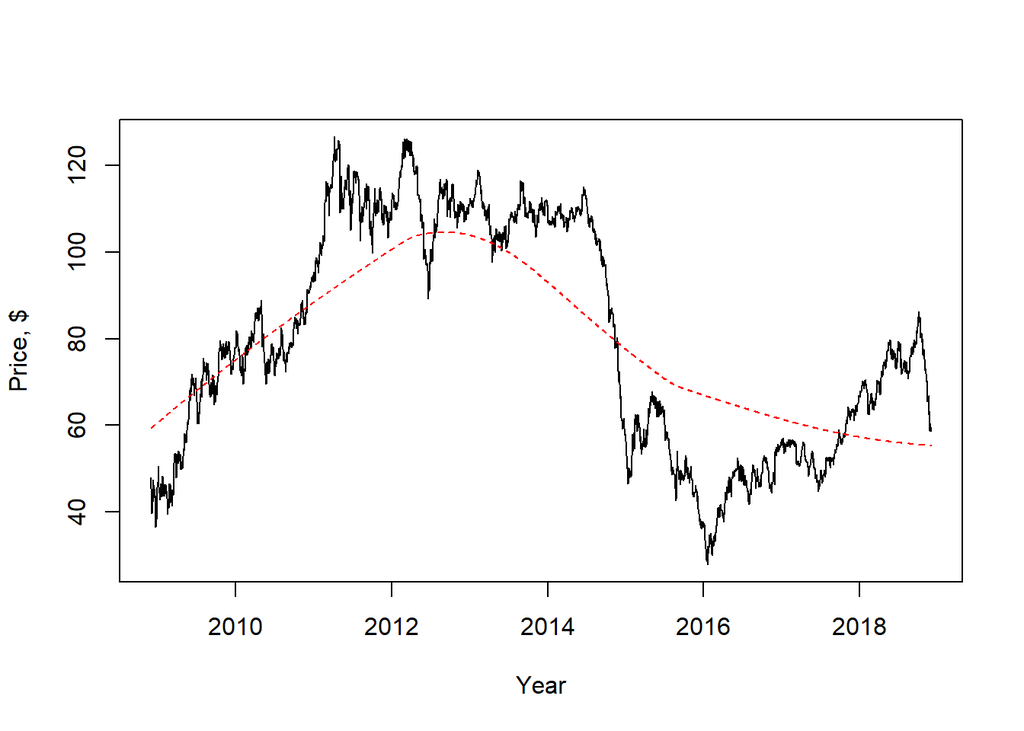

```r
plot(oil, xlab="Year", ylab="Price, $", type="l")
lines(lowess(oil), col="red", lty="dashed")
```

We first attempt to see if a log transformation is recommended by plotting the Box-Cox log likelihood graphs.

BoxCox plots to show the need of log transformation

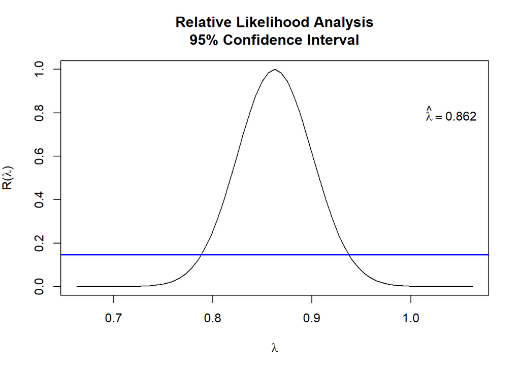

```r
BoxCox.ts(oil.ts)
```

Since estimated parameter lambda did not take the value of zero in its 95% confidence interval, we will not transform our data with ‘log’ operator.

First, we apply Dickey-Fuller stationarity test:

```r
adf.test(oil.ts, alternative=c('stationary'))
```

```
##
##  Augmented Dickey-Fuller Test
##
## data:  oil.ts
## Dickey-Fuller = -2.3004, Lag order = 13, p-value = 0.4511
## alternative hypothesis: stationary
```

Since p-value is greater than critical point, we do not reject the null hypothesis which claims that our time serie is non-stationary

# 2 ARIMA Models

## 2.1 DECIDE PARAMATERS ‘p’, ‘d’ and ‘q’ in ARIMA(p,d,q)

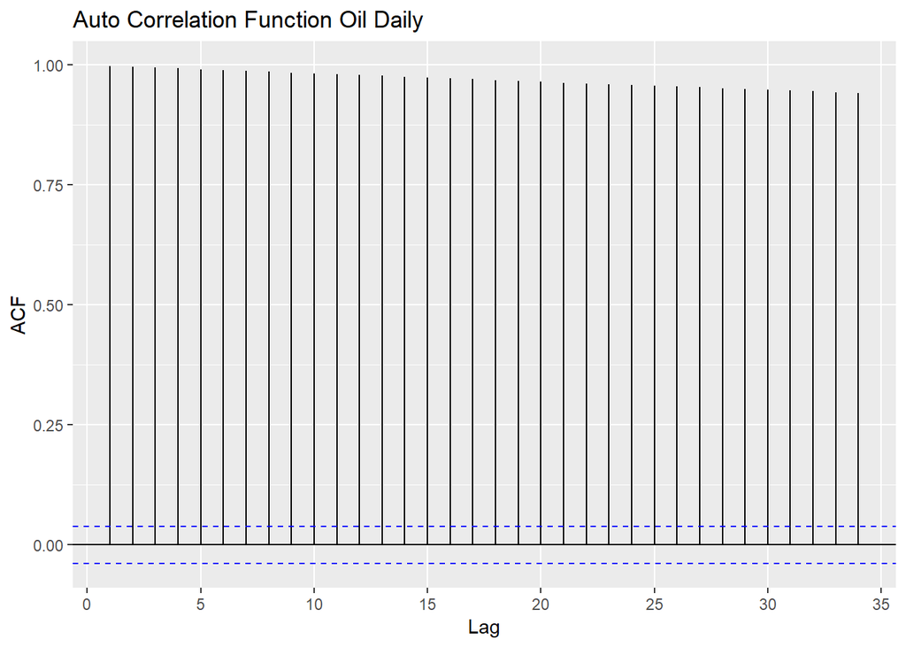

```r
library(ggplot2)
ggAcf(oil.ts) +
  ggtitle("Auto Correlation Function Oil Daily")
```

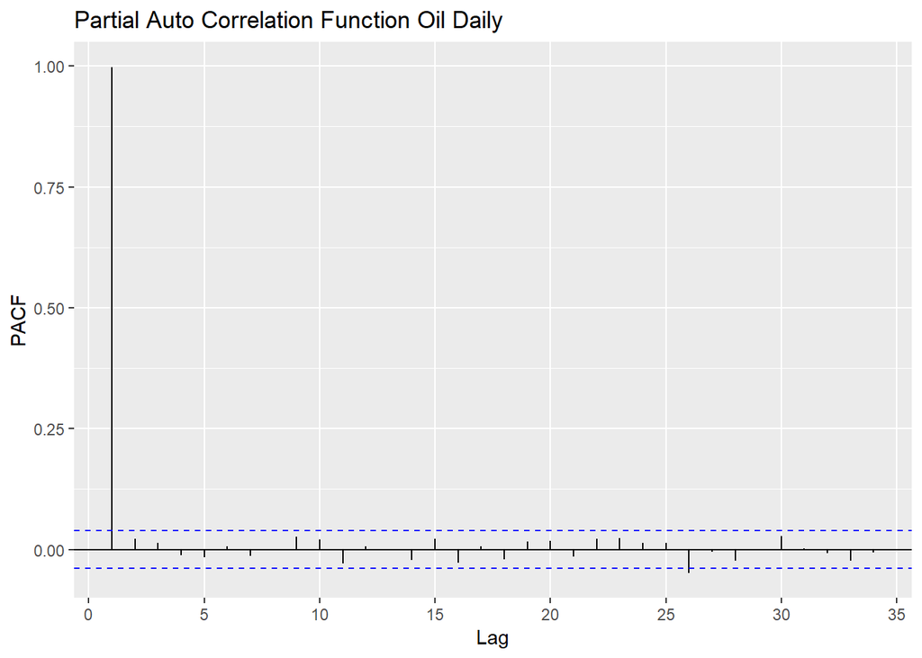

```r
ggPacf(oil.ts) +
  ggtitle("Partial Auto Correlation Function Oil Daily")
```

PACF graph tell us that the spikes exist in ACF graph caused by the lag 1.

Let’s take one lag differences of the series

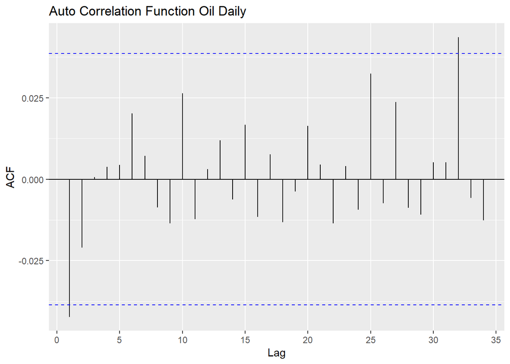

```r
ggAcf(diff(oil.ts,1)) +
  ggtitle("Auto Correlation Function Oil Daily")
```

Now perform an (Augmented) Dickey-Fuller Test. It is a test to see if a time series has a unit root. If it does, the series is considered non-stationary. The null hypothesis here is that the time series is non-stationary.

```r
adf.test(diff(oil.ts,1), alternative=c('stationary'))
```

```
##
##  Augmented Dickey-Fuller Test
##
## data:  diff(oil.ts, 1)
## Dickey-Fuller = -13.341, Lag order = 13, p-value = 0.01
## alternative hypothesis: stationary
```

Since the p-value is less than critical point (0,05), we reject null hypothesisand conclude that our new 1-lag-difference serie is stationary!

So we need to use ARIMA(0,1,?)

Plotting the variable that is clarified from its 1-lag relation…

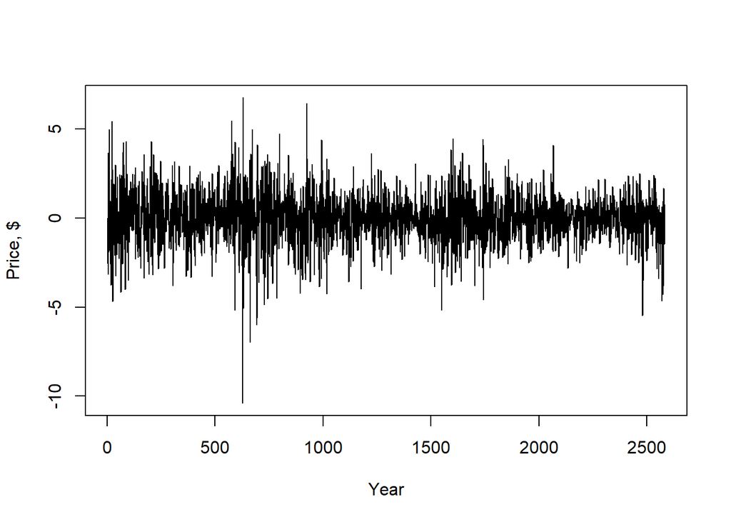

```r
plot(diff(oil.ts,1), xlab="Year", ylab="Price, $", type="l")
```

Writing a function to compute AIC of various ARMA orders

```r
AICfn<-function(N,K)
{
  for(i in 0:N)
  {for(j in 0:N)
  {
    print(AIC(arima(K,order=c(i,1,j))))
  }}}

AICfn(2,oil.ts)
```

```
## [1] 9065.469
## [1] 9062.644
## [1] 9063.523
## [1] 9062.855
## [1] 9063.793
## [1] 9065.521
## [1] 9063.513
## [1] 9065.51
## [1] 9067.519
```

ARIMA(0,1,1) model brings the minimum AIC…ARIMA(1,1,0) has the second lowest AIC…

We should take prediction performances into account while deciding best ARMA model parameters

## 2.2 Validation of the model

We will do it by selection with ‘auto.arima()’ built-in function in R:

```r
h <- 5
fit.arima <- auto.arima(oil.ts[1:2578], max.order = TRUE)
fit.arima
```

```
## Series: oil.ts[1:2578]
## ARIMA(1,1,1)
##
## Coefficients:
##          ar1      ma1
##       0.3308  -0.3738
## s.e.  0.2849   0.2794
##
## sigma^2 estimated as 1.958:  log likelihood=-4521.21
## AIC=9048.42   AICc=9048.43   BIC=9065.99
```

Fitted model by auto.arima is ARIMA(1,1,1)

We will compare all there arima models’ results

**Models determined**

```r
model1<-arima(oil.ts[1:2578],order=c(0,1,1),include.mean=FALSE)
model2<-arima(oil.ts[1:2578],order=c(1,1,0),include.mean=FALSE)
model3<-arima(oil.ts[1:2578],order=c(1,1,1),include.mean=FALSE)
```

**Residual analysis**

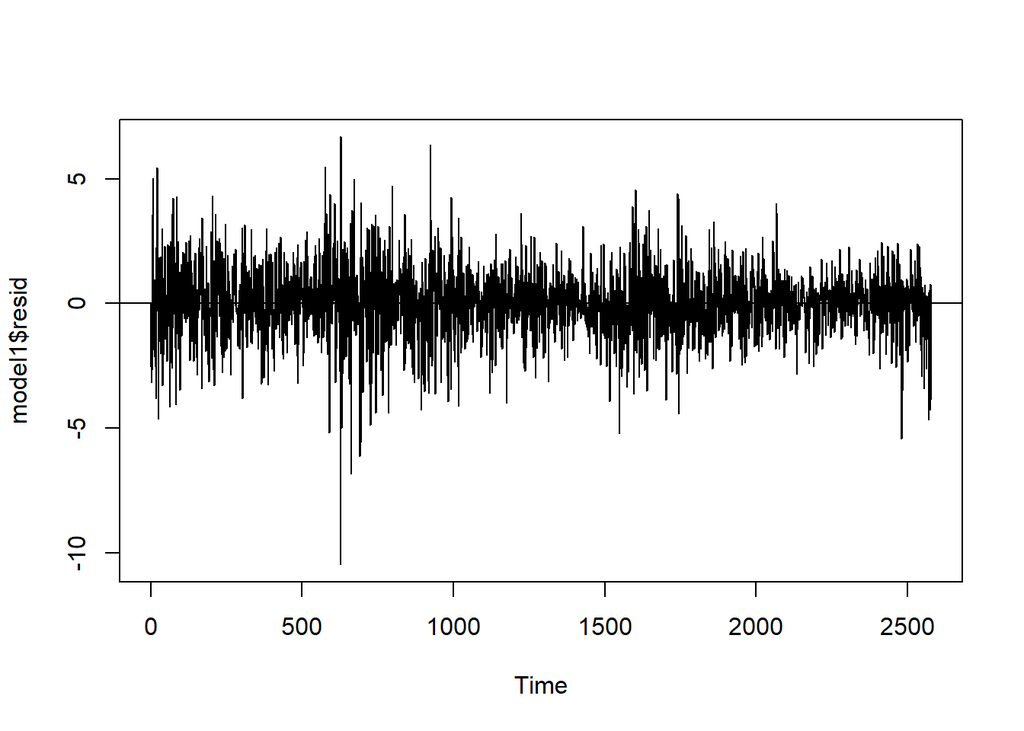

```r
plot(model1$resid);abline(h=0)
```

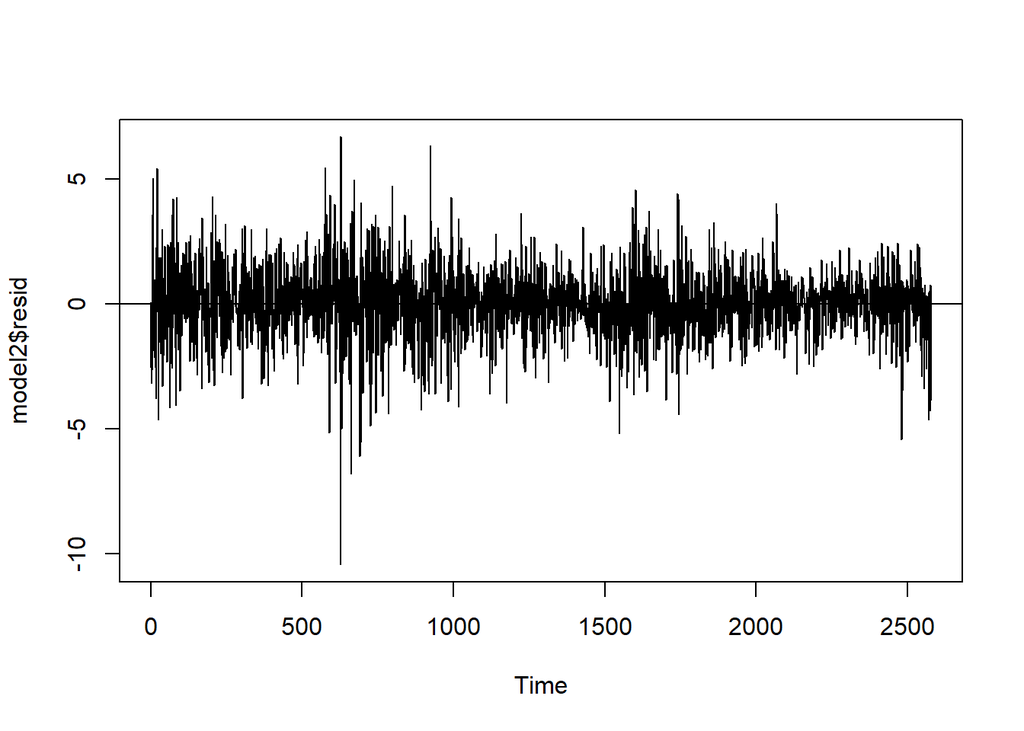

```r
plot(model2$resid);abline(h=0)
```

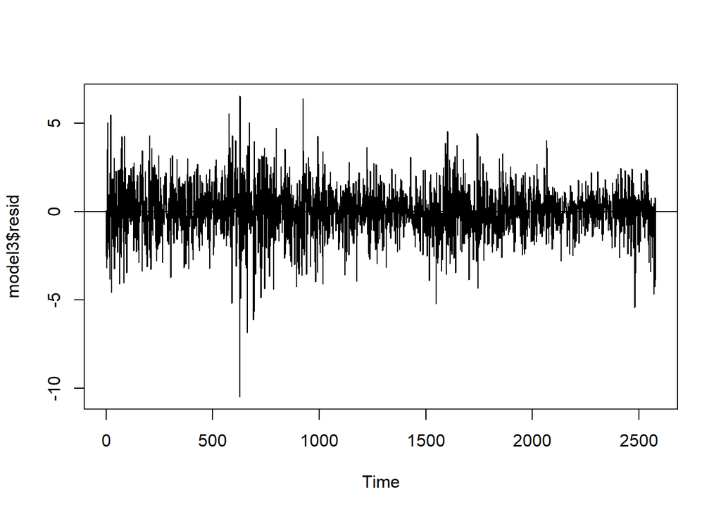

```r
plot(model3$resid);abline(h=0)
```

```r
mean(model1$resid); mean(model2$resid); mean(model3$resid)
```

```
## [1] 0.004474089
```

```
## [1] 0.004452038
```

```
## [1] 0.004622694
```

**Residual ACF and PACF plots**

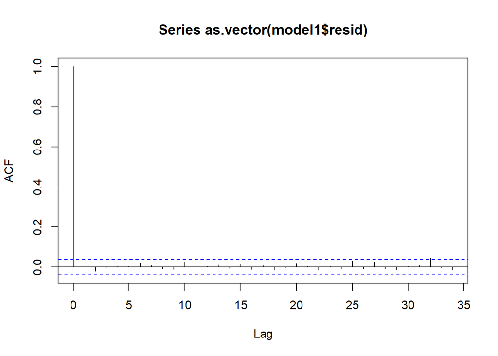

```r
acf(as.vector(model1$resid),drop.lag.0=FALSE)
```

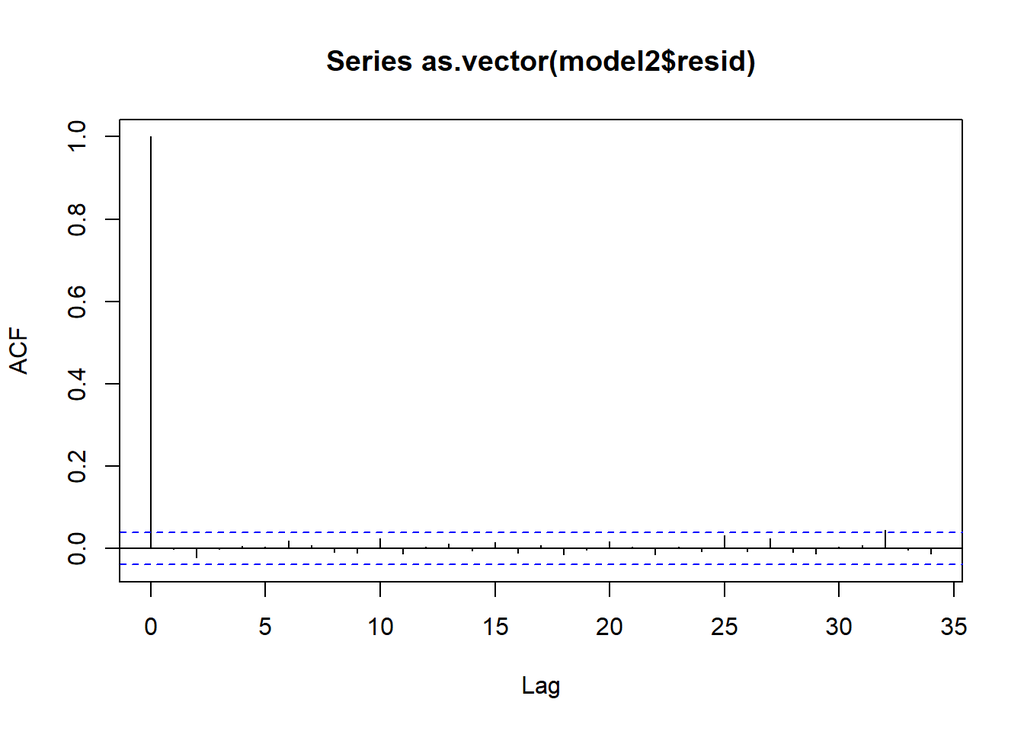

```r
acf(as.vector(model2$resid),drop.lag.0=FALSE)
```

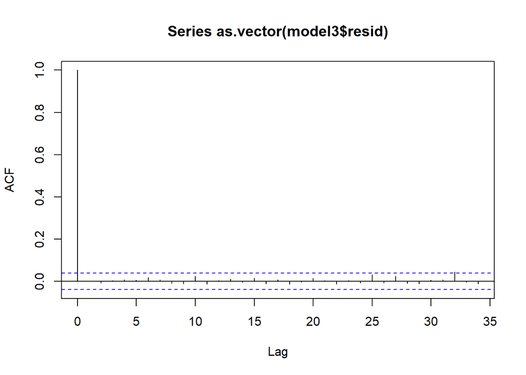

```r
acf(as.vector(model3$resid),drop.lag.0=FALSE)
```

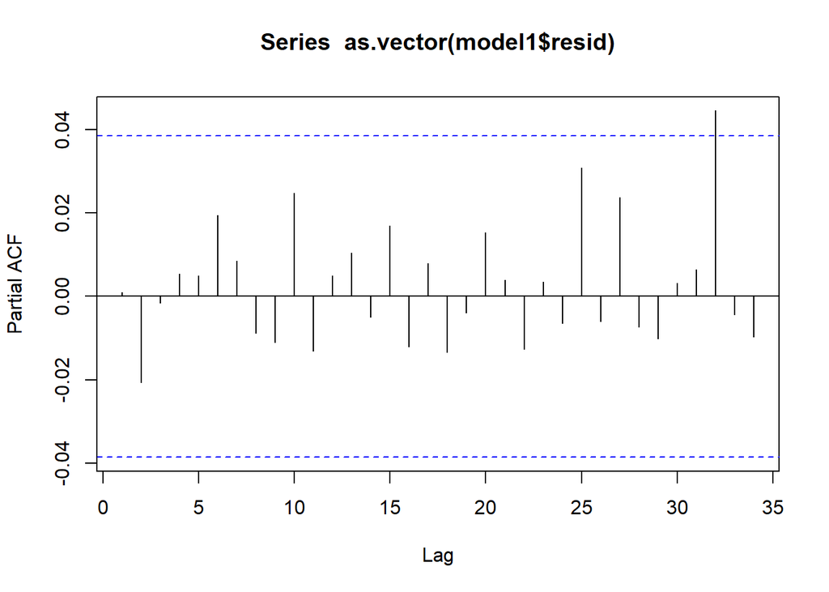

```r
pacf(as.vector(model1$resid))
```

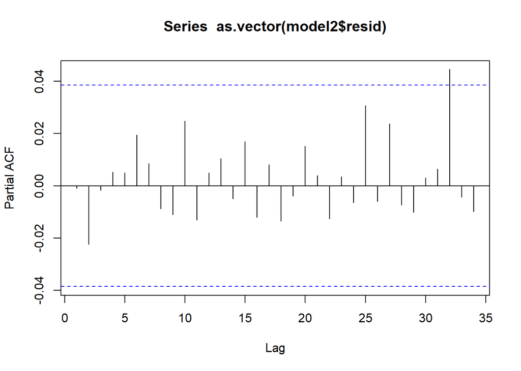

```r
pacf(as.vector(model2$resid))
```

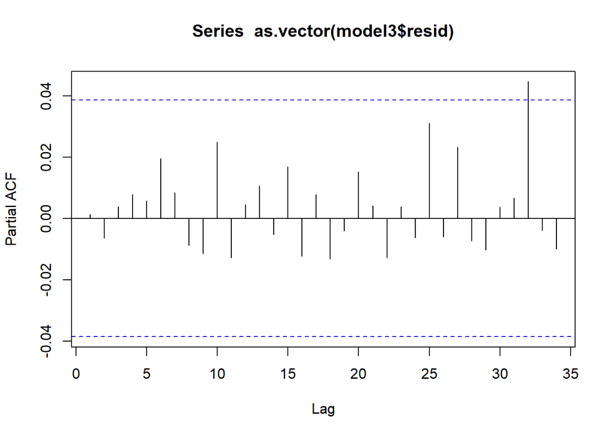

```r
pacf(as.vector(model3$resid))
```

**Normality tests**

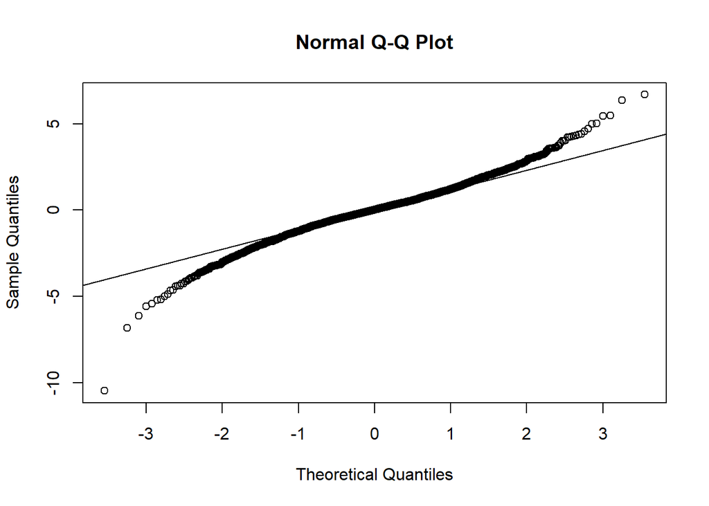

```r
qqnorm(residuals(model1)); qqline(residuals(model1))
```

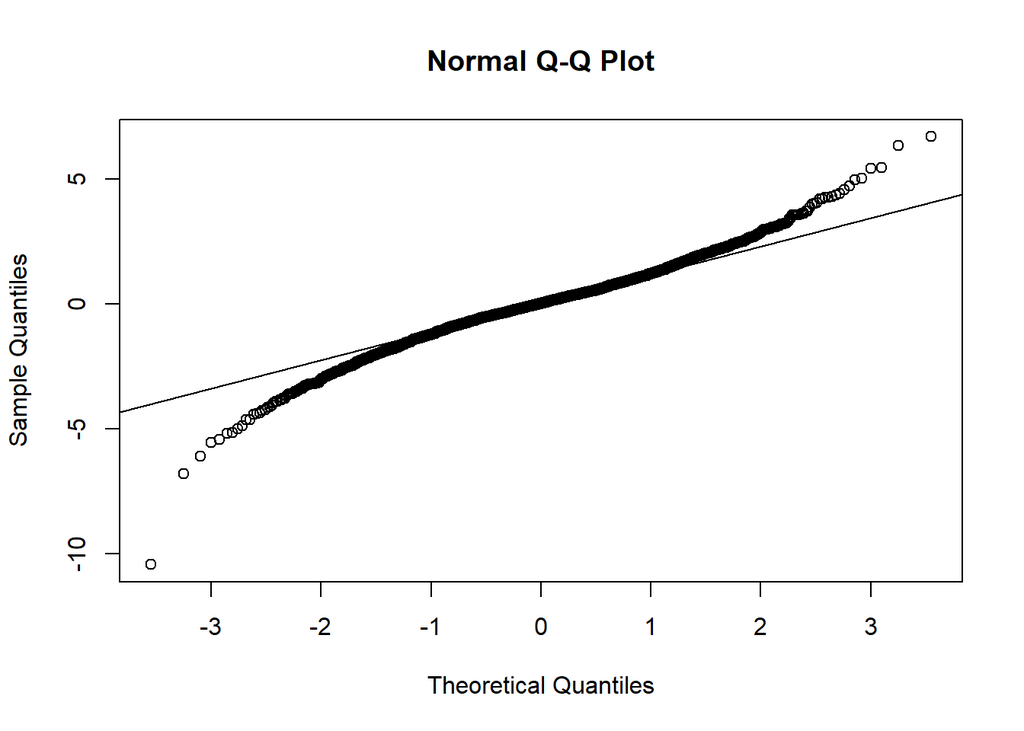

```r
qqnorm(residuals(model2)); qqline(residuals(model2))
```

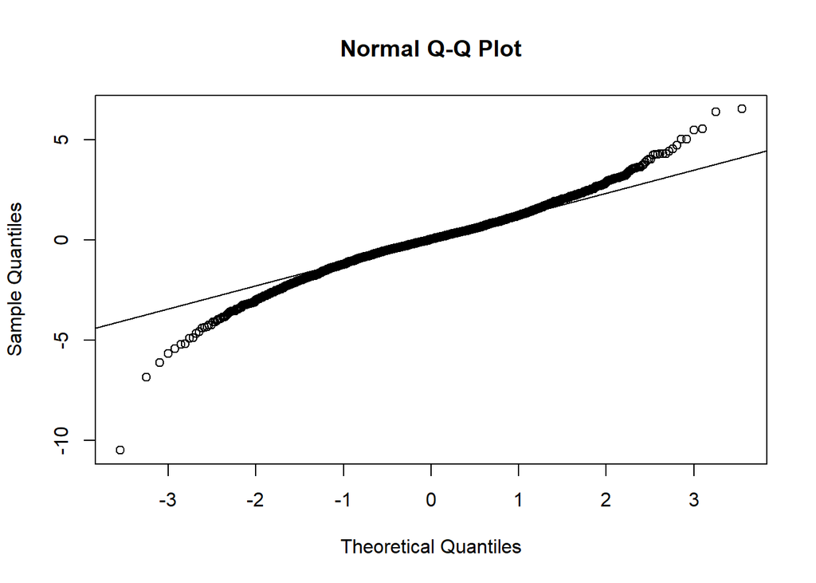

```r
qqnorm(residuals(model3)); qqline(residuals(model3))
```

```r
jarque.bera.test(model1$resid); jarque.bera.test(model2$resid); jarque.bera.test(model3$resid)
```

```
##
##  Jarque Bera Test
##
## data:  model1$resid
## X-squared = 816.22, df = 2, p-value < 2.2e-16
```

```
##
##  Jarque Bera Test
##
## data:  model2$resid
## X-squared = 815.77, df = 2, p-value < 2.2e-16
```

```
##
##  Jarque Bera Test
##
## data:  model3$resid
## X-squared = 821.66, df = 2, p-value < 2.2e-16
```

### 2.2.1 Independence tests

**McLeod, A. I. and W. K. Li (1983).**

**Diagnostic checking ARMA time series models using squared residual autocorrelations**

```r
library(TSA)
McLeod.Li.test(,model1$resid,gof.lag=20)
```

[output not shown]

```r
McLeod.Li.test(,model2$resid,gof.lag=20)
```

[output not shown]

```r
McLeod.Li.test(,model3$resid,gof.lag=20)
```

[output not shown]

Therefore, a GARCH model may be appropriate to fit the data. The intuitive rationale behind that is possibly linked to the fact that the financial crisis has brought in some significant effects of volatility clustering.

**Write a function to compute AICs of various GARCH orders**

```r
AICfn2<-function(N,K)
{
  for(i in 1:(N+1))
  { for(j in 1:N)
  {
    print(AIC(garch(residuals(K),order=c(i,j-1),trace=FALSE)))
  }}}

AICfn2(3,model1)
```

```
## [1] 9047.274
## [1] 8761.674
## [1] 8926.508
## [1] 9043.498
## [1] 8983.4
## [1] 8920.674
## [1] 9042.983
## [1] 8974.127
## [1] 8911.679
## [1] 9037.348
## [1] 8961.533
## [1] 8898.441
```

```r
AICfn2(3,model2)
```

```
## [1] 9047.467
## [1] 8761.695
## [1] 8926.613
## [1] 9043.692
## [1] 8983.584
## [1] 8920.769
## [1] 9043.177
## [1] 8974.294
## [1] 8911.761
## [1] 9037.557
## [1] 8961.702
## [1] 8898.524
```

```r
AICfn2(3,model3)
```

```
## [1] 9046.42
## [1] 8762.101
## [1] 8926.509
## [1] 9042.645
## [1] 8983.374
## [1] 8920.728
## [1] 9042.131
## [1] 8974.228
## [1] 8911.837
## [1] 9036.379
## [1] 8961.309
## [1] 8898.61
```

GARCH(1,1) gives minimum AIC score for model1 (ARIMA(0,1,1)), model2 (ARIMA(1,1,0)) and model3 (ARIMA(1,1,1))

**GARCH model fitted**

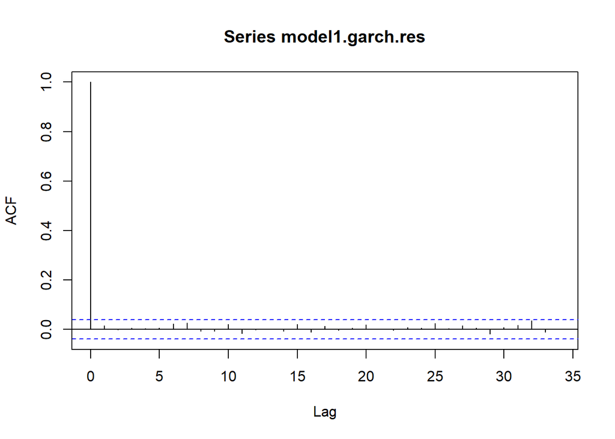

```r
model1.garch<-garch(model1$resid,order=c(1,1),trace=F)
model2.garch<-garch(model2$resid,order=c(1,1),trace=F)
model3.garch<-garch(model3$resid,order=c(1,1),trace=F)

model1.garch.res<-resid(model1.garch)[-1]
model2.garch.res<-resid(model2.garch)[-1]
model3.garch.res<-resid(model3.garch)[-1]

acf(model1.garch.res,drop.lag.0=FALSE, na.action = na.pass)
```

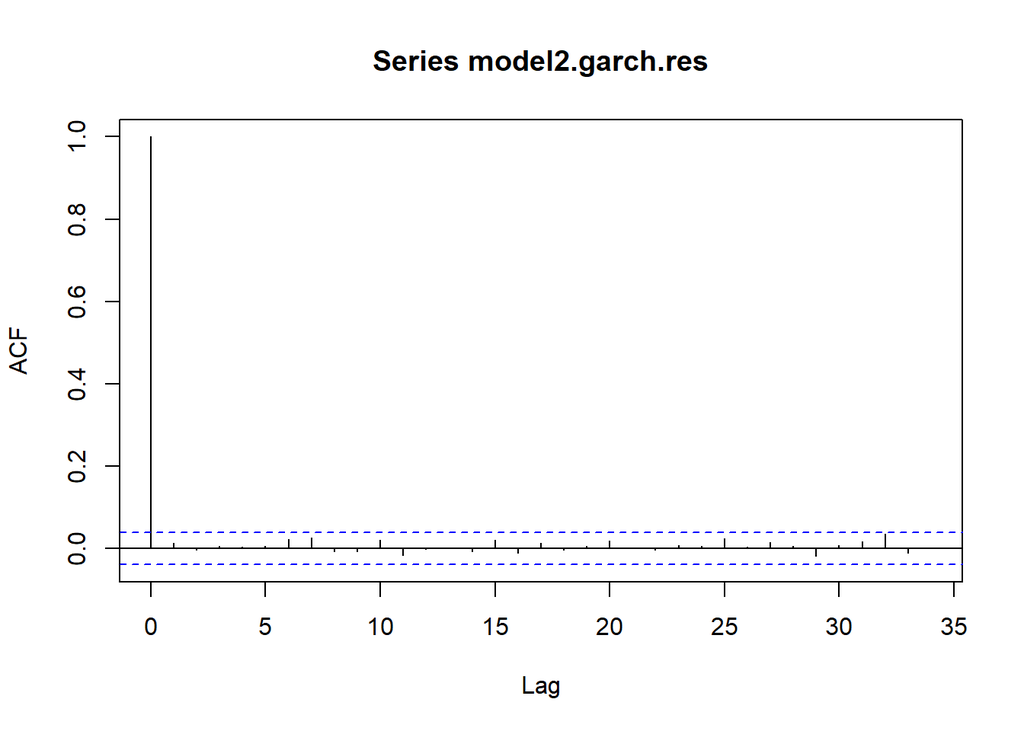

```r
acf(model2.garch.res,drop.lag.0=FALSE, na.action = na.pass)
```

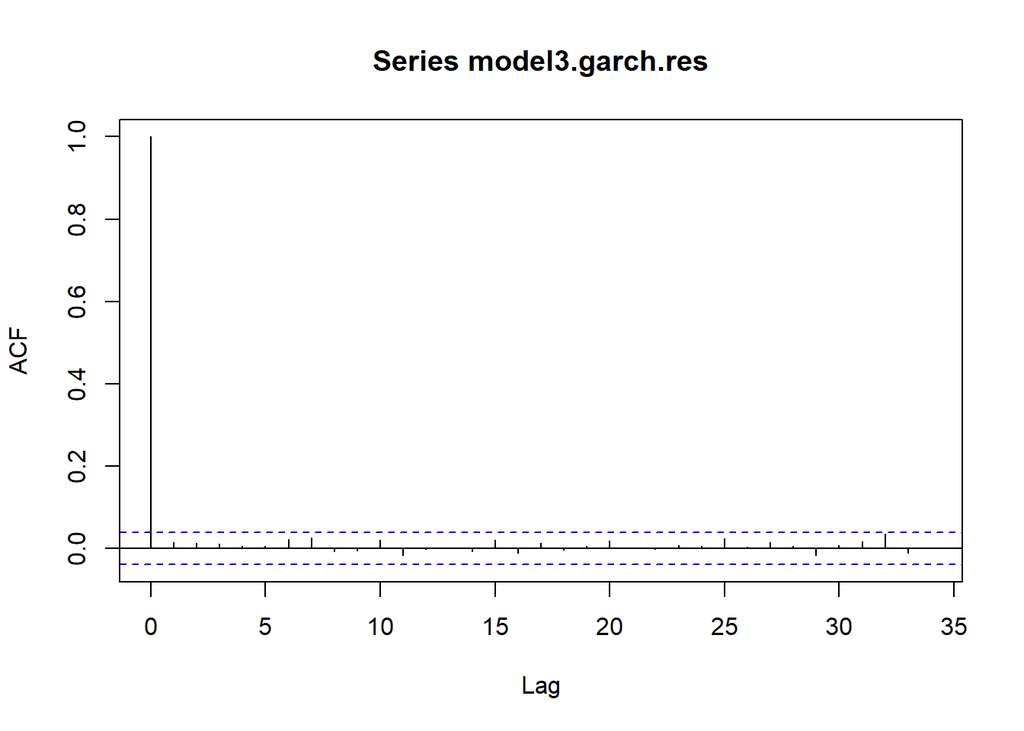

```r
acf(model3.garch.res,drop.lag.0=FALSE, na.action = na.pass)
```

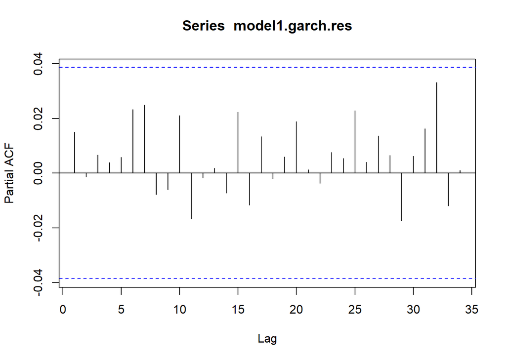

```r
pacf(model1.garch.res, na.action = na.pass)
```

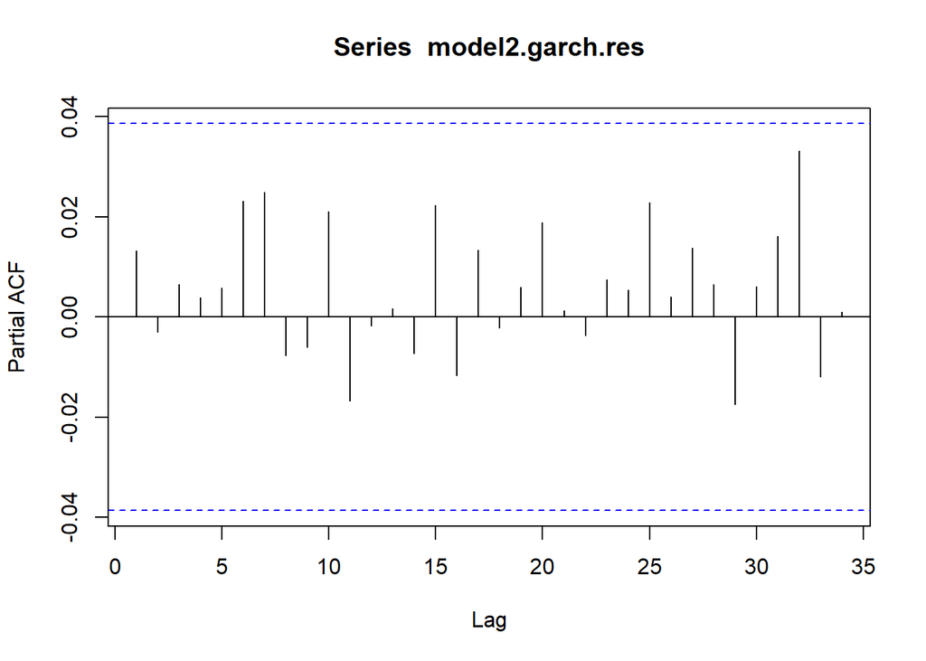

```r
pacf(model2.garch.res, na.action = na.pass)
```

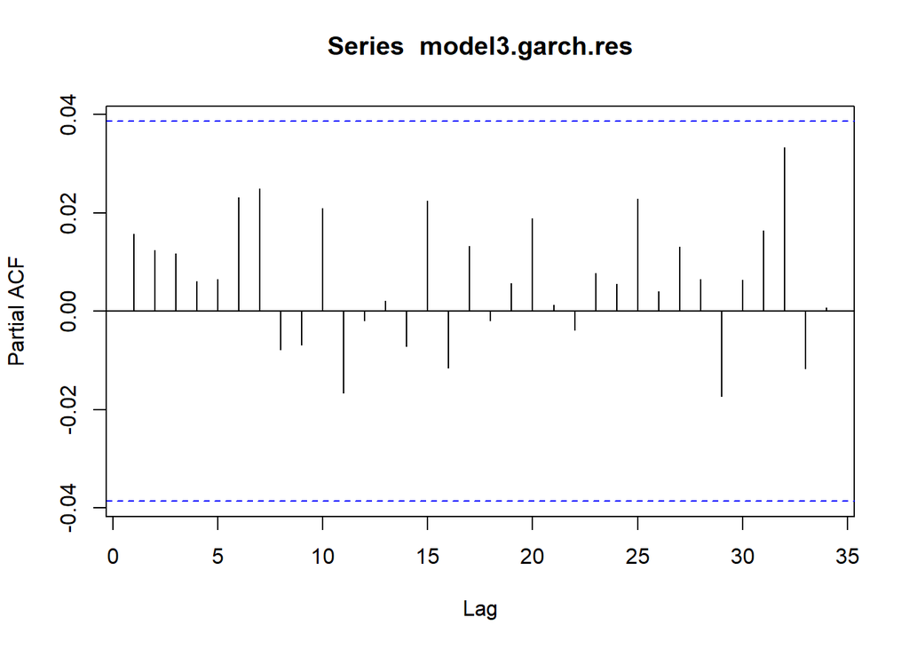

```r
pacf(model3.garch.res, na.action = na.pass)
```

**For comparing forecast accuracy, fit GARCH/APARCH models**

```r
library(fGarch)
gfit11<-garchFit(formula=~arma(0,1)+garch(1,1),
                data=oil.ts[1:2578],trace=FALSE,include.mean=FALSE)
gfit12<-garchFit(formula=~arma(0,1)+aparch(1,1),
                 data=oil.ts[1:2578],trace=FALSE,include.mean=FALSE)
gfit21<-garchFit(formula=~arma(1,0)+garch(1,1),
                data=oil.ts[1:2578],trace=FALSE,include.mean=FALSE)#, hessian = 'rcd')
gfit22<-garchFit(formula=~arma(1,0)+aparch(1,1),
                 data=oil.ts[1:2578],trace=FALSE,include.mean=FALSE)
gfit31<-garchFit(formula=~arma(1,1)+garch(1,1),
                 data=oil.ts[1:2578],trace=FALSE,include.mean=FALSE)#, hessian = 'rcd')# OR use cond.dist = "QMLE"
gfit32<-garchFit(formula=~arma(1,1)+aparch(1,1),
                 data=oil.ts[1:2578],trace=FALSE,include.mean=FALSE)
```

We used ‘hessian’ parameter as default for ‘garchfit.predict’ method which is denoting how the Hessian matrix should be evaluated. But optimization of likelihood brings coefficient of GARCH model which are NaN, since the optimization will not converge and the diagonal elements in Hessian Matrix finalized as ‘negative’ which causes an infinite standard errors! (taking sqrt of nagative brings irrationality) covariance matrix should be positive definite !!!

We should deep dive into garchfit() method and optim() method in order to manage convergence. So, since GARCH models are beyond the limitations of our scope, we leave them at this point

https://ntguardian.wordpress.com/2017/11/02/problems-estimating-garch-parameters-r/

http://r.789695.n4.nabble.com/Problem-with-garchFit-function-in-fSeries-td803321.html

https://www.rdocumentation.org/packages/fGarch/versions/3042.83/topics/garchFit

https://people.duke.edu/~rnau/411arim3.htm

**Omitted GARCH Models are:**

forecast.error11[i]<-mean(abs(predict(gfit11,n.ahead=i)$meanForecast-oil.ts[(2579:(2578+i))]));

forecast.error12[i]<-mean(abs(predict(gfit12,n.ahead=i)$meanForecast-oil.ts[(2579:(2578+i))]));

forecast.error21[i]<-mean(abs(predict(gfit21,n.ahead=i)$meanForecast-oil.ts[(2579:(2578+i))])); predict(gfit21,n.ahead=i,cond.dist = “QMLE”)

forecast.error22[i]<-mean(abs(predict(gfit22,n.ahead=i)$meanForecast-oil.ts[(2579:(2578+i))]));

forecast.error31[i]<-mean(abs(predict(gfit21,n.ahead=i)$meanForecast-oil.ts[(2579:(2578+i))]));

forecast.error32[i]<-mean(abs(predict(gfit22,n.ahead=i)$meanForecast-oil.ts[(2579:(2578+i))]));

## 2.3 Forecasting

We continue with ARIMA type models and omit GARCH components by assuming that the residuals are not autocorrelated, though the McLeod-Li test indicates a strong evidence that the residuals are autocorrelated.

```r
forecast.error41 <- vector(length=5)
forecast.error42 <- vector(length=5)
forecast.error43 <- vector(length=5)

for(i in 1:5)

{
  forecast.error41[i]<-mean(abs(forecast(Arima(oil.ts[1:2578],
                                             order=c(1,1,0),include.mean=FALSE),
                                       h=5)$mean-oil.ts[(2579:(2578+i))]));
forecast.error42[i]<-mean(abs(forecast(Arima(oil.ts[1:2578],
                                             order=c(0,1,1),include.mean=FALSE),
                                       h=5)$mean-oil.ts[(2579:(2578+i))]));
forecast.error43[i]<-mean(abs(forecast(Arima(oil.ts[1:2578],
                                             order=c(1,1,1),include.mean=FALSE),
                                       h=5)$mean-oil.ts[(2579:(2578+i))]))
}

forecast.error41
```

```
## [1] 1.5297797 1.4217797 1.1534042 1.0134042 0.7550246
```

```r
forecast.error42
```

```
## [1] 1.516305 1.408305 1.145783 1.005783 0.753261
```

```r
forecast.error43
```

```
## [1] 1.4356887 1.3276887 1.1041636 0.9641636 0.7541329
```

**Compute MAE**

```r
mean(abs(forecast.error41))
```

```
## [1] 1.174678
```

```r
mean(abs(forecast.error42))
```

```
## [1] 1.165887
```

```r
mean(abs(forecast.error43))
```

```
## [1] 1.117168
```

So our MAE values are about 1. It is not bad. Let’s see if we can develop it by NAR models.

# 3 NAR Models

Now, we will try NAR methods to predict oil prices.

**Statistics about data**

```r
des_oil.ts = stat.desc(oil.ts)
des_oil.ts
```

```
##                         x
## nbr.val      2.583000e+03
## nbr.null     0.000000e+00
## nbr.na       0.000000e+00
## min          2.788000e+01
## max          1.266500e+02
## range        9.877000e+01
## sum          2.060512e+05
## median       7.665000e+01
## mean         7.977204e+01
## SE.mean      5.151931e-01
## CI.mean.0.95 1.010234e+00
## var          6.855900e+02
## std.dev      2.618377e+01
## coef.var     3.282325e-01
```

**Skewness**

```r
s_oil.ts = skewness(oil.ts)
s_oil.ts
```

```
## [1] 0.0494875
```

```r
k_oil.ts<-kurtosis(oil.ts)
k_oil.ts
```

```
## [1] 1.598019
```

We’ve done analysis like stationarity above, so we won’t repeat them here. We’ll advance directly to NAR Models. **Splitting dataset into train and test**

```r
oiltrain = oil.ts[1:2578]
oiltest = oil.ts[2579:2583] #We take last 5 observations as test (h)
```

We will use 2 models in two different packages

## 3.1 Model-1

**Fit NN with 20 nodes, d=1 for stationarity**

```r
fit.nn <- nnetar(y = oiltrain, d =1, size= 20)
fcast.nn <- forecast(fit.nn, h=5) # forecast 5 days
```

**Predicted Values**

```r
fcast.nn
```

```
##      Point Forecast
## 2579       59.50868
## 2580       58.95322
## 2581       58.75395
## 2582       58.45662
## 2583       58.18895
```

**Summary of the model**

```r
summary(fcast.nn)
```

```
##
## Forecast method: NNAR(2,20)
##
## Model Information:
##
## Average of 20 networks, each of which is
## a 2-20-1 network with 81 weights
## options were - linear output units  decay=1
##
## Error measures:
##                       ME     RMSE      MAE         MPE     MAPE     MASE
## Training set 0.002549162 1.473955 1.101593 -0.07703823 1.561309 1.066366
##                   ACF1
## Training set 0.2764916
##
## Forecasts:
##      Point Forecast
## 2579       59.50868
## 2580       58.95322
## 2581       58.75395
## 2582       58.45662
## 2583       58.18895
```

**Let’s see real and predicted values in one table**

```r
nntable = cbind(oiltest, fcast.nn$mean)
nntable
```

```
## Time Series:
## Start = 2579
## End = 2583
## Frequency = 1
##      oiltest fcast.nn$mean
## 2579   60.48      59.50868
## 2580   60.21      58.95322
## 2581   58.76      58.75395
## 2582   59.51      58.45662
## 2583   58.71      58.18895
```

**And it is time for results for our first model**

```r
MAPE_nn = mean(abs(oiltest-fcast.nn$mean)/oiltest)
MAPE_nn
```

```
## [1] 0.01272246
```

```r
MAE_nn = mean(abs(oiltest-fcast.nn$mean))
MAE_nn
```

```
## [1] 0.7617161
```

Lets try a different library.

## 3.2 Model-2

**Training the model and fitting it.**

```r
fit.nnet = nnetTs(oiltrain,d =1, m = 3, size = 20)
summary(fit.nnet)
```

```
##
## Non linear autoregressive model
##
## NNET time series model
## a 3-20-1 network with 101 weights
## options were - linear output units
##
## Residuals:
##         Min          1Q      Median          3Q         Max
## -8.99914853 -0.80280209 -0.02571679  0.79857617  7.15187742
##
## Fit:
## residuals variance = 2.076,  AIC = 2086, MAPE = 1.493%
```

```r
fcast.nnet = forecast(object = oiltrain, h=5)
summary(fcast.nnet)
```

```
##
## Forecast method: ETS(A,N,N)
##
## Model Information:
## ETS(A,N,N)
##
## Call:
##  ets(y = object, lambda = lambda, biasadj = biasadj, allow.multiplicative.trend = allow.multiplicative.trend)
##
##   Smoothing parameters:
##     alpha = 0.9572
##
##   Initial states:
##     l = 47.8529
##
##   sigma:  1.3992
##
##      AIC     AICc      BIC
## 21985.33 21985.34 22002.89
##
## Error measures:
##                       ME     RMSE      MAE         MPE     MAPE      MASE
## Training set 0.004503067 1.398612 1.030778 -0.01354981 1.444574 0.9978154
##                     ACF1
## Training set 0.001020738
##
## Forecasts:
##      Point Forecast    Lo 80    Hi 80    Lo 95    Hi 95
## 2579       58.96438 57.17129 60.75747 56.22209 61.70667
## 2580       58.96438 56.48230 61.44646 55.16837 62.76039
## 2581       58.96438 55.94672 61.98203 54.34927 63.57949
## 2582       58.96438 55.49281 62.43595 53.65507 64.27369
## 2583       58.96438 55.09174 62.83702 53.04169 64.88707
```

**Real values vs. predicted values**

```r
nntable = cbind(oiltest, fcast.nnet$mean)
nntable
```

```
## Time Series:
## Start = 2579
## End = 2583
## Frequency = 1
##      oiltest fcast.nnet$mean
## 2579   60.48        58.96438
## 2580   60.21        58.96438
## 2581   58.76        58.96438
## 2582   59.51        58.96438
## 2583   58.71        58.96438
```

**And the results:**

```r
MAPE_nnet = mean(abs(oiltest-fcast.nnet$mean)/oiltest)
MAPE_nnet
```

```
## [1] 0.01254548
```

```r
MAE_nnet = mean(abs(oiltest-fcast.nnet$mean))
MAE_nnet
```

```
## [1] 0.7531244
```